# BA Individual Assignment

### This code snippet is incomplete and only demonstrates the core processing logic. It assumes the Feedback dataset already exists. Please extend the code and answer the questions. When writing your own code, you need to fully specify the dataframe and include all necessary steps.

2a) The provided code snippet is incomplete and demonstrates the core processing logic of performing text preprocessing and word frequency analysis on customer feedback data to identify the most commonly used words after removing meaningless stopwords. Modify the code to add two new columns to the CustomerFeedback dataset: most_frequent_word: The most frequently occurring word in each feedback (after stopword removal); word_count: The count of that most frequent word (10 pts).

Hint: You may use the following functions: slice(); left_join().

```r
library(tidyverse)
library(tidytext)
library(ggplot2)

CustomerFeedback <- read.csv("CustomerFeedback.csv", stringsAsFactors = FALSE)

data("stop_words")

CustomerFeedback <- CustomerFeedback %>%
  mutate(Feedback_ID = row_number())

feedback_tokens <- CustomerFeedback %>%
  unnest_tokens(word, Feedback_Text) %>%
  anti_join(stop_words, by = "word") %>%
  count(Feedback_ID, word, sort = TRUE)
  top_words <- feedback_tokens %>%
  group_by(Feedback_ID) %>%
  slice(1) %>%
  ungroup() %>%
  rename(most_frequent_word = word,
         word_count = n)

CustomerFeedback <- CustomerFeedback %>%
  left_join(top_words, by = "Feedback_ID")

CustomerFeedback <- CustomerFeedback %>%
  mutate(
    most_frequent_word = ifelse(is.na(most_frequent_word),
                                "no_meaningful_words",
                                most_frequent_word),
    word_count = ifelse(is.na(word_count), 0, word_count)
  )

head(CustomerFeedback)
```

```
##   CustomerID Rating Feedback_ID                              Feedback_Text
## 1       C101      4           1   Fast shipping, but packaging was damaged
## 2       C102      5           2            Perfect product! Will buy again
## 3       C103      3           3               Product works but overpriced
## 4       C104      1           4 Never received my order - terrible service
## 5       C105      4           5     Customer service ignored my complaints
## 6       C106      4           6  Excellent build quality and fast delivery
##   Response_Time_Days Preferred_Contact Churn_Risk Sentiment most_frequent_word
## 1                  5             Phone     Medium     -0.11            damaged
## 2                  8             Email       High      0.98                buy
## 3                  9             Phone        Low      0.12         overpriced
## 4                  7             Phone       High     -0.82           received
## 5                  9             Email       High     -0.33         complaints
## 6                  2             Email       High      0.91              build
##   word_count
## 1          1
## 2          1
## 3          1
## 4          1
## 5          1
## 6          1
```

2b) If the most frequent word in the most_frequent_word column of a CustomerFeedback dataset is “okay,” can we conclude that the overall user sentiment is positive? Justify your answer.(10 pts).

Answer: Even though the most frequently word appeared in CustomerFeedback dataset is okay”, it doesn’t mean that the overall user sentiment is positive. Because the okay is a neutral word, it can’t express the extreme positive mood. To more accurately analyze the feedback of customers, we should use the full text sentiment analysis to analysis the tone and emotion of the text, instead of only analyzing the most frequently appeared words.

2c) The column “Sentiment” is the result of a sentiment analysis on customers’ textual feedback, its values range from -1 [most negative] to +1 [most positive]). The dataset also includes a Rating column (e.g., 1–5 stars). Task(10 pts): Write R code to: 1. Calculate the correlation coefficient between the Sentiment (numeric values ranging from -1 to +1) and Rating (e.g., 1–5 stars) columns in the dataset. 2. Visualize the relationship between these two variables using an appropriate plot, and describe their relationship.

```r
library(dplyr)
library(ggplot2)
correlation_value <- cor(CustomerFeedback$Sentiment,
                         CustomerFeedback$Rating,
                         use = "complete.obs")

print(paste("Correlation between Sentiment and Rating:",
            round(correlation_value, 3)))
```

```
## [1] "Correlation between Sentiment and Rating: 0.711"
```

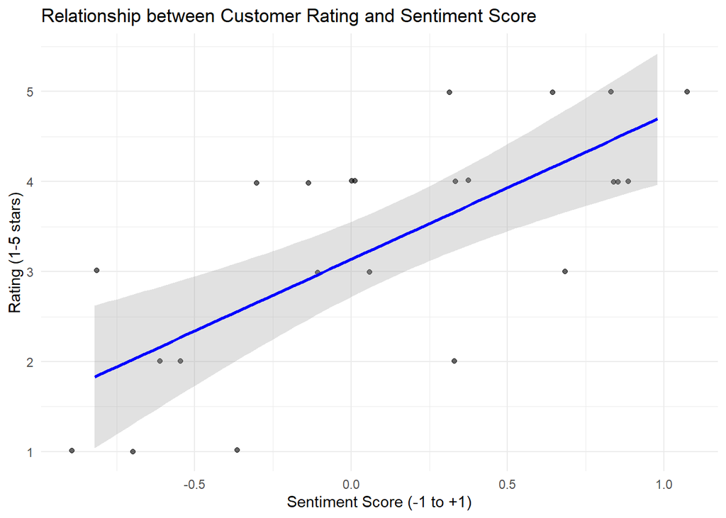

```r
ggplot(CustomerFeedback, aes(x = Sentiment, y = Rating)) +
  geom_point(alpha = 0.6, position = position_jitter(width = 0.1, height = 0.02)) +
  geom_smooth(method = "lm", se = TRUE, color = "blue", alpha = 0.3) +
  labs(title = "Relationship between Customer Rating and Sentiment Score",
       x = "Sentiment Score (-1 to +1)",
       y = "Rating (1-5 stars)")+
  theme_minimal()
```